# Predictive Modelling on Big Mart Sales Data

#### This piece of code includes a full machine learning project including the whole pipeline of operations outlined below:

1. data preparation
2. data cleaning
3. choosing models
4. training a model
5. evaluating the model
6. make predictions

The packages used in this programming are: Pandas, Numpy, Scikit-Learn

The *'Big Mart Predictive Sales Report'* accompanies this code and demonstrates understanding of **ethical design**.

```python
# Import necessary libraries

import pandas as pd
pd.options.mode.chained_assignment = None  # default='warn'

import numpy as np
import matplotlib.pyplot as plt
%matplotlib inline
import seaborn as sns
```

### Importing Data from Excel

```python
# test_df = test data frame

test_df = pd.read_csv(r'C:\Users\Aalis\Documents\Documents\Data Science\SEM 2\Software Development\Big Mart Sales Data\Test.csv')

# train_df = train data frame

train_df = pd.read_csv(r"C:\Users\Aalis\Documents\Documents\Data Science\SEM 2\Software Development\Big Mart Sales Data\Train.csv")
```

```python
# checking they have imported correctly

test_df.head()

#train_df.head()
```

|  | Item_Identifier | Item_Weight | Item_Fat_Content | Item_Visibility | Item_Type | Item_MRP | Outlet_Identifier | Outlet_Establishment_Year | Outlet_Size | Outlet_Location_Type | Outlet_Type |
| --- | --- | --- | --- | --- | --- | --- | --- | --- | --- | --- | --- |
| 0 | FDW58 | 20.750 | Low Fat | 0.007565 | Snack Foods | 107.8622 | OUT049 | 1999 | Medium | Tier 1 | Supermarket Type1 |
| 1 | FDW14 | 8.300 | reg | 0.038428 | Dairy | 87.3198 | OUT017 | 2007 | NaN | Tier 2 | Supermarket Type1 |
| 2 | NCN55 | 14.600 | Low Fat | 0.099575 | Others | 241.7538 | OUT010 | 1998 | NaN | Tier 3 | Grocery Store |
| 3 | FDQ58 | 7.315 | Low Fat | 0.015388 | Snack Foods | 155.0340 | OUT017 | 2007 | NaN | Tier 2 | Supermarket Type1 |
| 4 | FDY38 | NaN | Regular | 0.118599 | Dairy | 234.2300 | OUT027 | 1985 | Medium | Tier 3 | Supermarket Type3 |

```python
# merge both test and train just to fill in missing values

train_df['Source'] = 'train'
test_df['Source'] = 'test'
df=pd.concat([train_df,test_df], ignore_index=True)
```

## Data Cleaning

Both test and train are cleaned because the test set reflects the system's performance against real-time data, you need to perform a clean-up of the data in the test set.

The only difference between the two sets are:

- the size
- the sales column in test is empty

```python
# Summative Statistisc

df.describe()
```

|  | Item_Weight | Item_Visibility | Item_MRP | Outlet_Establishment_Year | Item_Outlet_Sales |
| --- | --- | --- | --- | --- | --- |
| count | 11765.000000 | 14204.000000 | 14204.000000 | 14204.000000 | 8523.000000 |
| mean | 12.792854 | 0.065953 | 141.004977 | 1997.830681 | 2181.288914 |
| std | 4.652502 | 0.051459 | 62.086938 | 8.371664 | 1706.499616 |
| min | 4.555000 | 0.000000 | 31.290000 | 1985.000000 | 33.290000 |
| 25% | 8.710000 | 0.027036 | 94.012000 | 1987.000000 | 834.247400 |
| 50% | 12.600000 | 0.054021 | 142.247000 | 1999.000000 | 1794.331000 |
| 75% | 16.750000 | 0.094037 | 185.855600 | 2004.000000 | 3101.296400 |
| max | 21.350000 | 0.328391 | 266.888400 | 2009.000000 | 13086.964800 |

```python
# Information on data types


test_df.info()
train_df.info()
df.info()
```

```
<class 'pandas.core.frame.DataFrame'>
RangeIndex: 5681 entries, 0 to 5680
Data columns (total 12 columns):
 #   Column                     Non-Null Count  Dtype
---  ------                     --------------  -----
 0   Item_Identifier            5681 non-null   object
 1   Item_Weight                4705 non-null   float64
 2   Item_Fat_Content           5681 non-null   object
 3   Item_Visibility            5681 non-null   float64
 4   Item_Type                  5681 non-null   object
 5   Item_MRP                   5681 non-null   float64
 6   Outlet_Identifier          5681 non-null   object
 7   Outlet_Establishment_Year  5681 non-null   int64
 8   Outlet_Size                4075 non-null   object
 9   Outlet_Location_Type       5681 non-null   object
 10  Outlet_Type                5681 non-null   object
 11  Source                     5681 non-null   object
dtypes: float64(3), int64(1), object(8)
memory usage: 532.7+ KB
<class 'pandas.core.frame.DataFrame'>
RangeIndex: 8523 entries, 0 to 8522
Data columns (total 13 columns):
 #   Column                     Non-Null Count  Dtype
---  ------                     --------------  -----
 0   Item_Identifier            8523 non-null   object
 1   Item_Weight                7060 non-null   float64
 2   Item_Fat_Content           8523 non-null   object
 3   Item_Visibility            8523 non-null   float64
 4   Item_Type                  8523 non-null   object
 5   Item_MRP                   8523 non-null   float64
 6   Outlet_Identifier          8523 non-null   object
 7   Outlet_Establishment_Year  8523 non-null   int64
 8   Outlet_Size                6113 non-null   object
 9   Outlet_Location_Type       8523 non-null   object
 10  Outlet_Type                8523 non-null   object
 11  Item_Outlet_Sales          8523 non-null   float64
 12  Source                     8523 non-null   object
dtypes: float64(4), int64(1), object(8)
memory usage: 865.7+ KB
<class 'pandas.core.frame.DataFrame'>
RangeIndex: 14204 entries, 0 to 14203
Data columns (total 13 columns):
 #   Column                     Non-Null Count  Dtype
---  ------                     --------------  -----
 0   Item_Identifier            14204 non-null  object
 1   Item_Weight                11765 non-null  float64
 2   Item_Fat_Content           14204 non-null  object
 3   Item_Visibility            14204 non-null  float64
 4   Item_Type                  14204 non-null  object
 5   Item_MRP                   14204 non-null  float64
 6   Outlet_Identifier          14204 non-null  object
 7   Outlet_Establishment_Year  14204 non-null  int64
 8   Outlet_Size                10188 non-null  object
 9   Outlet_Location_Type       14204 non-null  object
 10  Outlet_Type                14204 non-null  object
 11  Item_Outlet_Sales          8523 non-null   float64
 12  Source                     14204 non-null  object
dtypes: float64(4), int64(1), object(8)
memory usage: 1.4+ MB
```

## Data Cleaning Plan

Example of Changes -

- Item_Weight - empty points to N/A
- Item_Fat_Content - LF, Low Fat, low fat to Low; Reg to Regular

```python
# Cleaning column names

def clean_col(col):
    col = col.strip()
    col = col.replace("Item_Identifier", "Item_Id")
    col = col.replace("Outlet_Identifier", "Outlet_Id")
    col = col.replace(" ","_")
    col = col.title()
    return col

new_columns = []
for c in df.columns:
    clean_c = clean_col(c)
    new_columns.append(clean_c)

df.columns = new_columns

print(df)
```

```
      Item_Id  Item_Weight Item_Fat_Content  Item_Visibility  \
0       FDA15         9.30          Low Fat         0.016047
1       DRC01         5.92          Regular         0.019278
2       FDN15        17.50          Low Fat         0.016760
3       FDX07        19.20          Regular         0.000000
4       NCD19         8.93          Low Fat         0.000000
...       ...          ...              ...              ...
14199   FDB58        10.50          Regular         0.013496
14200   FDD47         7.60          Regular         0.142991
14201   NCO17        10.00          Low Fat         0.073529
14202   FDJ26        15.30          Regular         0.000000
14203   FDU37         9.50          Regular         0.104720

                   Item_Type  Item_Mrp Outlet_Id  Outlet_Establishment_Year  \
0                      Dairy  249.8092    OUT049                       1999
```

[output cut: 38 more lines]

```python
# print(train_df["Item_Weight"].value_counts())
# print(train_df["Item_Visibility"].value_counts())
# print(train_df["Item_Mrp"].value_counts())
# print(train_df["Outlet_Establishment_Year"].value_counts())
#print(train_df["Item_Outlet_Sales"].value_counts())
```

```python
print(df["Item_Fat_Content"].value_counts())
```

```
Low Fat    8485
Regular    4824
LF          522
reg         195
low fat     178
Name: Item_Fat_Content, dtype: int64
```

```python
# Cleaning up irregularities in the column data

df['Item_Fat_Content'] = df['Item_Fat_Content'].replace(['Low Fat', 'low fat', 'LF', 'reg'], ['Low', 'Low', 'Low', 'Regular'])
print(df["Item_Fat_Content"].value_counts())
```

```
Low        9185
Regular    5019
Name: Item_Fat_Content, dtype: int64
```

```python
print(df["Item_Type"].value_counts())
```

```
Fruits and Vegetables    2013
Snack Foods              1989
Household                1548
Frozen Foods             1426
Dairy                    1136
Baking Goods             1086
Canned                   1084
Health and Hygiene        858
Meat                      736
Soft Drinks               726
Breads                    416
Hard Drinks               362
Others                    280
Starchy Foods             269
Breakfast                 186
Seafood                    89
Name: Item_Type, dtype: int64
```

```python
df['Item_Type'] = df['Item_Type'].replace(['Hard Drinks', 'Others'],['Alcohol', 'Other'])
print(df["Item_Type"].value_counts())
```

```
Fruits and Vegetables    2013
Snack Foods              1989
Household                1548
Frozen Foods             1426
Dairy                    1136
Baking Goods             1086
Canned                   1084
Health and Hygiene        858
Meat                      736
Soft Drinks               726
Breads                    416
Alcohol                   362
Other                     280
Starchy Foods             269
Breakfast                 186
Seafood                    89
Name: Item_Type, dtype: int64
```

```python
print(df["Outlet_Id"].value_counts())
```

```
OUT027    1559
OUT013    1553
OUT049    1550
OUT046    1550
OUT035    1550
OUT045    1548
OUT018    1546
OUT017    1543
OUT010     925
OUT019     880
Name: Outlet_Id, dtype: int64
```

This shows the number of items in a dataset that have come from the specific outlet Id.

For instance we can see: OUT019 has the least number of items sold.

```python
print(df["Outlet_Size"].value_counts())
```

```
Medium    4655
Small     3980
High      1553
Name: Outlet_Size, dtype: int64
```

it's important to note that outlet size refers to the ground area of the shop.

```python
print(df["Outlet_Location_Type"].value_counts())
```

```
Tier 3    5583
Tier 2    4641
Tier 1    3980
Name: Outlet_Location_Type, dtype: int64
```

Tier 1,2,3 refer to the size of the city that eachs store is located in but it doesn't state explicitly which tier refers to which size.

```python
print(df["Outlet_Type"].value_counts())
```

```
Supermarket Type1    9294
Grocery Store        1805
Supermarket Type3    1559
Supermarket Type2    1546
Name: Outlet_Type, dtype: int64
```

Supermarket will sell everthing, grocery stores just sell fruit and veg.

### Treating Missing Values

```python
# how many null values are there
df.isnull().sum()
```

```
Item_Id                         0
Item_Weight                  2439
Item_Fat_Content                0
Item_Visibility                 0
Item_Type                       0
Item_Mrp                        0
Outlet_Id                       0
Outlet_Establishment_Year       0
Outlet_Size                  4016
Outlet_Location_Type            0
Outlet_Type                     0
Item_Outlet_Sales            5681
Source                          0
dtype: int64
```

```python
df
```

|  | Item_Id | Item_Weight | Item_Fat_Content | Item_Visibility | Item_Type | Item_Mrp | Outlet_Id | Outlet_Establishment_Year | Outlet_Size | Outlet_Location_Type | Outlet_Type | Item_Outlet_Sales | Source |
| --- | --- | --- | --- | --- | --- | --- | --- | --- | --- | --- | --- | --- | --- |
| 0 | FDA15 | 9.30 | Low | 0.016047 | Dairy | 249.8092 | OUT049 | 1999 | Medium | Tier 1 | Supermarket Type1 | 3735.1380 | train |
| 1 | DRC01 | 5.92 | Regular | 0.019278 | Soft Drinks | 48.2692 | OUT018 | 2009 | Medium | Tier 3 | Supermarket Type2 | 443.4228 | train |
| 2 | FDN15 | 17.50 | Low | 0.016760 | Meat | 141.6180 | OUT049 | 1999 | Medium | Tier 1 | Supermarket Type1 | 2097.2700 | train |
| 3 | FDX07 | 19.20 | Regular | 0.000000 | Fruits and Vegetables | 182.0950 | OUT010 | 1998 | NaN | Tier 3 | Grocery Store | 732.3800 | train |
| 4 | NCD19 | 8.93 | Low | 0.000000 | Household | 53.8614 | OUT013 | 1987 | High | Tier 3 | Supermarket Type1 | 994.7052 | train |
| ... | ... | ... | ... | ... | ... | ... | ... | ... | ... | ... | ... | ... | ... |
| 14199 | FDB58 | 10.50 | Regular | 0.013496 | Snack Foods | 141.3154 | OUT046 | 1997 | Small | Tier 1 | Supermarket Type1 | NaN | test |
| 14200 | FDD47 | 7.60 | Regular | 0.142991 | Starchy Foods | 169.1448 | OUT018 | 2009 | Medium | Tier 3 | Supermarket Type2 | NaN | test |
| 14201 | NCO17 | 10.00 | Low | 0.073529 | Health and Hygiene | 118.7440 | OUT045 | 2002 | NaN | Tier 2 | Supermarket Type1 | NaN | test |
| 14202 | FDJ26 | 15.30 | Regular | 0.000000 | Canned | 214.6218 | OUT017 | 2007 | NaN | Tier 2 | Supermarket Type1 | NaN | test |
| 14203 | FDU37 | 9.50 | Regular | 0.104720 | Canned | 79.7960 | OUT045 | 2002 | NaN | Tier 2 | Supermarket Type1 | NaN | test |

14204 rows × 13 columns

```python
# Replace Blank values with DataFrame.replace() methods.
# this loses test

# keep the original for comparison
df_original = df

# merge back to sort missing values

# DONT WANT TO REPLACE SALES VALUES IN TEST SET
train = df.loc[df['Source'] == 'train']
test = df.loc[df['Source'] == 'test']
```

```python
test.isnull().sum()
```

```
Item_Id                         0
Item_Weight                   976
Item_Fat_Content                0
Item_Visibility                 0
Item_Type                       0
Item_Mrp                        0
Outlet_Id                       0
Outlet_Establishment_Year       0
Outlet_Size                  1606
Outlet_Location_Type            0
Outlet_Type                     0
Item_Outlet_Sales            5681
Source                          0
dtype: int64
```

```python
train.isnull().sum()
```

```
Item_Id                         0
Item_Weight                  1463
Item_Fat_Content                0
Item_Visibility                 0
Item_Type                       0
Item_Mrp                        0
Outlet_Id                       0
Outlet_Establishment_Year       0
Outlet_Size                  2410
Outlet_Location_Type            0
Outlet_Type                     0
Item_Outlet_Sales               0
Source                          0
dtype: int64
```

```python
#train = train.replace(r'^\s*$', np.nan, regex=True)
```

```python
df
```

|  | Item_Id | Item_Weight | Item_Fat_Content | Item_Visibility | Item_Type | Item_Mrp | Outlet_Id | Outlet_Establishment_Year | Outlet_Size | Outlet_Location_Type | Outlet_Type | Item_Outlet_Sales | Source |
| --- | --- | --- | --- | --- | --- | --- | --- | --- | --- | --- | --- | --- | --- |
| 0 | FDA15 | 9.30 | Low | 0.016047 | Dairy | 249.8092 | OUT049 | 1999 | Medium | Tier 1 | Supermarket Type1 | 3735.1380 | train |
| 1 | DRC01 | 5.92 | Regular | 0.019278 | Soft Drinks | 48.2692 | OUT018 | 2009 | Medium | Tier 3 | Supermarket Type2 | 443.4228 | train |
| 2 | FDN15 | 17.50 | Low | 0.016760 | Meat | 141.6180 | OUT049 | 1999 | Medium | Tier 1 | Supermarket Type1 | 2097.2700 | train |
| 3 | FDX07 | 19.20 | Regular | 0.000000 | Fruits and Vegetables | 182.0950 | OUT010 | 1998 | NaN | Tier 3 | Grocery Store | 732.3800 | train |
| 4 | NCD19 | 8.93 | Low | 0.000000 | Household | 53.8614 | OUT013 | 1987 | High | Tier 3 | Supermarket Type1 | 994.7052 | train |
| ... | ... | ... | ... | ... | ... | ... | ... | ... | ... | ... | ... | ... | ... |
| 14199 | FDB58 | 10.50 | Regular | 0.013496 | Snack Foods | 141.3154 | OUT046 | 1997 | Small | Tier 1 | Supermarket Type1 | NaN | test |
| 14200 | FDD47 | 7.60 | Regular | 0.142991 | Starchy Foods | 169.1448 | OUT018 | 2009 | Medium | Tier 3 | Supermarket Type2 | NaN | test |
| 14201 | NCO17 | 10.00 | Low | 0.073529 | Health and Hygiene | 118.7440 | OUT045 | 2002 | NaN | Tier 2 | Supermarket Type1 | NaN | test |
| 14202 | FDJ26 | 15.30 | Regular | 0.000000 | Canned | 214.6218 | OUT017 | 2007 | NaN | Tier 2 | Supermarket Type1 | NaN | test |
| 14203 | FDU37 | 9.50 | Regular | 0.104720 | Canned | 79.7960 | OUT045 | 2002 | NaN | Tier 2 | Supermarket Type1 | NaN | test |

14204 rows × 13 columns

#### Item_Weight

```python
# filling all the missing values with a mean.

mean_weight = df['Item_Weight'].mean()

print(mean_weight)
```

```
12.792854228644991
```

```python
df['Item_Weight'].fillna(value=mean_weight, inplace=True)
```

#### Outlet_Size

```python
# filling outlet size in with the most frequent size = medium

df['Outlet_Size'].fillna('Medium', inplace=True)
```

#### Item Visibility

```python
df['Item_Visibility'].fillna(df['Item_Visibility'].median(), inplace=True)
```

```python
# check that there are no null values now

df.isnull().sum() #now we do not have any null values in Outlet_Size
```

```
Item_Id                         0
Item_Weight                     0
Item_Fat_Content                0
Item_Visibility                 0
Item_Type                       0
Item_Mrp                        0
Outlet_Id                       0
Outlet_Establishment_Year       0
Outlet_Size                     0
Outlet_Location_Type            0
Outlet_Type                     0
Item_Outlet_Sales            5681
Source                          0
dtype: int64
```

### Changing columns

#### New_Item_Type

```python
#Changing only the first 2 characters (i.e. the category ID)

df['New_Item_Type'] = df['Item_Id'].apply(lambda x: x[0:2])
```

```python
df['New_Item_Type'] = df['New_Item_Type'].map({'FD':'Food','NC':'Non-Consumable','DR':'Drinks'})
df['New_Item_Type'].value_counts()
```

```
Food              10201
Non-Consumable     2686
Drinks             1317
Name: New_Item_Type, dtype: int64
```

```python
df.loc[df['New_Item_Type']=='Non-Consumable','Item_Fat_Content']= "Non-Edible"
df['Item_Fat_Content'].value_counts()
```

```
Low           6499
Regular       5019
Non-Edible    2686
Name: Item_Fat_Content, dtype: int64
```

#### Item_visib_avg

```python
item_visib_avg = df.pivot_table(values='Item_Visibility', index='Item_Id')
```

```python
item_visib_avg
```

| Item_Id | Item_Visibility |
| --- | --- |
| DRA12 | 0.034938 |
| DRA24 | 0.045646 |
| DRA59 | 0.133384 |
| DRB01 | 0.079736 |
| DRB13 | 0.006799 |
| ... | ... |
| NCZ30 | 0.027302 |
| NCZ41 | 0.056396 |
| NCZ42 | 0.011015 |
| NCZ53 | 0.026330 |
| NCZ54 | 0.081345 |

1559 rows × 1 columns

```python
function = lambda x: x['Item_Visibility']/item_visib_avg['Item_Visibility'][item_visib_avg.index == x['Item_Id']][0]
df['item_visib_avg'] = df.apply(function,axis=1).astype(float)
```

#### Outlet_Years

```python
df['Outlet_Years'] = 2009-df['Outlet_Establishment_Year']
df['Outlet_Years'].describe()
```

```
count    14204.000000
mean        11.169319
std          8.371664
min          0.000000
25%          5.000000
50%         10.000000
75%         22.000000
max         24.000000
Name: Outlet_Years, dtype: float64
```

```python
df['Outlet_Years']
```

```
0        10
1         0
2        10
3        11
4        22
         ..
14199    12
14200     0
14201     7
14202     2
14203     7
Name: Outlet_Years, Length: 14204, dtype: int64
```

# Data Visualisations and Analysis

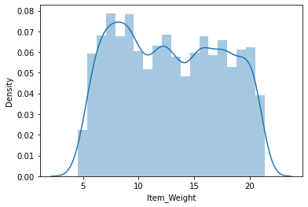

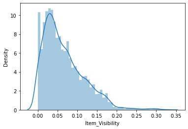

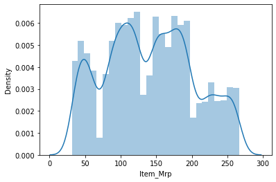

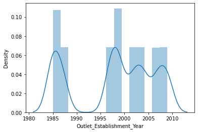

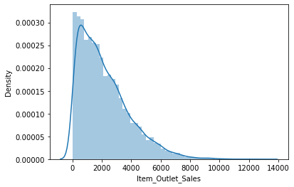

```python
# a graph to show the distribution - a distribution plot

for i in train.describe().columns:
    sns.distplot(train[i].dropna())
    plt.show()
```

### Item Visibility

- visibility is very right skewed, majority of the values are low.
- most items we buy in a supermarket are essentials so either don't require 'good visibility' as they are ingreidients that customers solely go into a shop for.
- meat and dairy are considered as essentials and they are kept in a fridge, typically located at the back of the shop.

### Outlet Establishment

- shows that the most previous outlet was established in 2009.

### Item Outlet Sales

- right skewed again
- majority are between 0 and 7000

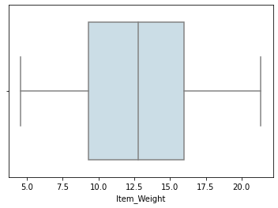

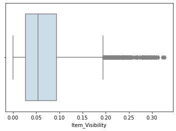

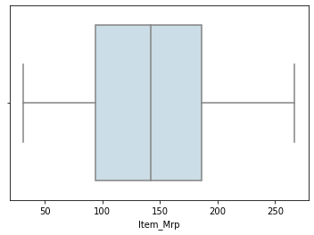

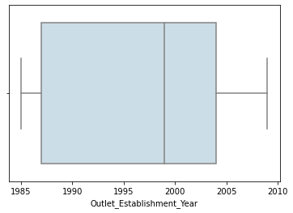

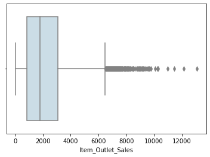

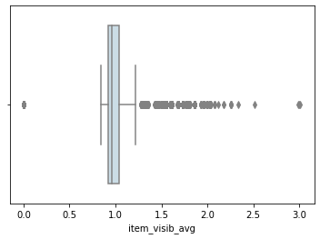

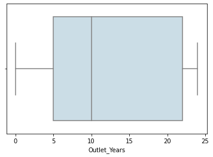

```python
# also showing distribution witha  box plot
# but boxplot shows the outliers which is easier to talk about!


for i in df.describe().columns:
    sns.boxplot(df[i].dropna(), palette = "ch:s=.25,rot=-.25")
    plt.show()
```

```
(array([ 0,  1,  2,  3,  4,  5,  6,  7,  8,  9, 10, 11, 12, 13, 14, 15]),
 [Text(0, 0, 'Dairy'),
```

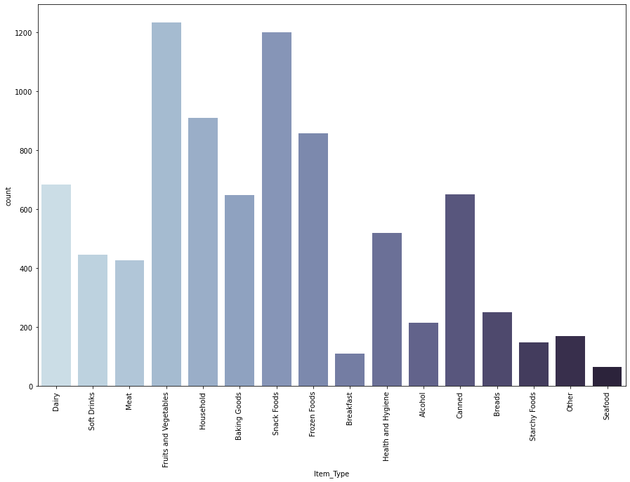

```python
# a bar plot

# colours to match techniflow logo

plt.figure(figsize=(15,10))
sns.countplot(train.Item_Type, palette = "ch:s=.25,rot=-.25")
plt.xticks(rotation=90)
```

```
(array([0, 1, 2]),
 [Text(0, 0, 'Medium'), Text(1, 0, 'High'), Text(2, 0, 'Small')])
```

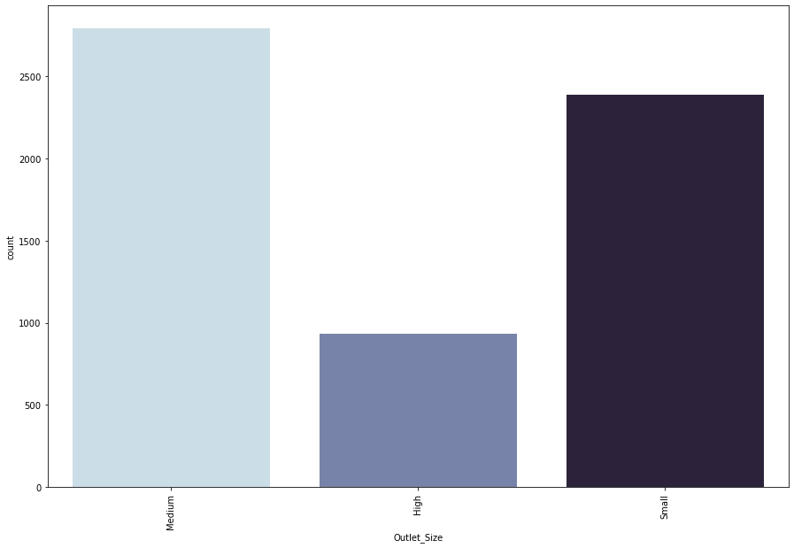

```python
# a bar plot with outlet size


plt.figure(figsize=(15,10))
sns.countplot(train.Outlet_Size, palette = "ch:s=.25,rot=-.25")
plt.xticks(rotation=90)
```

```
(array([0, 1, 2, 3]),
 [Text(0, 0, 'Supermarket Type1'),
```

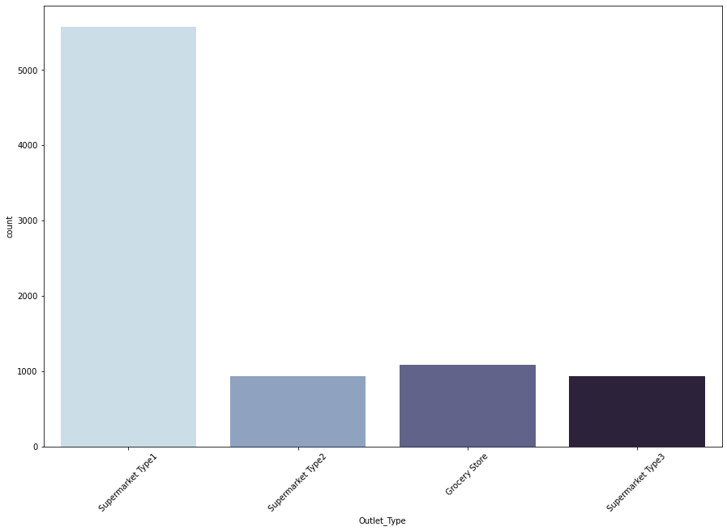

```python
# a bar plot with outlet type


plt.figure(figsize=(15,10))
sns.countplot(train.Outlet_Type, palette = "ch:s=.25,rot=-.25")
plt.xticks(rotation=45)
```

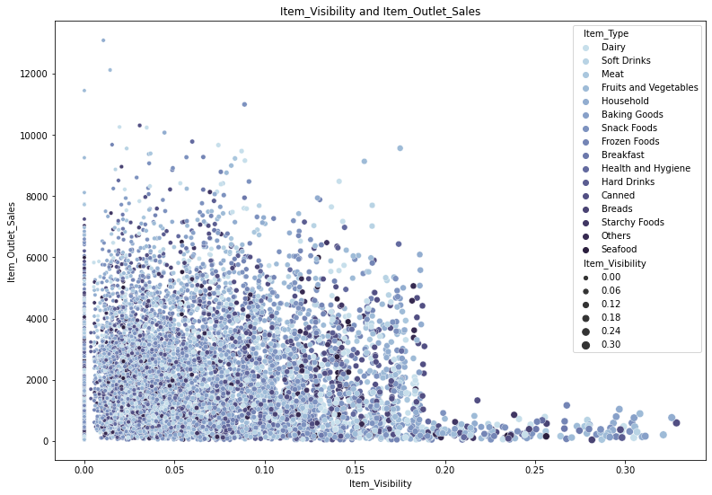

```python
# a scatter plot showing item visibility and sales, but not sure how helpful it is? the variable can be changed to item weight etc

plt.figure(figsize=(13,9))
plt.xlabel('Item_Visibility')
plt.ylabel('Item_Outlet_Sales')
plt.title('Item_Visibility and Item_Outlet_Sales')
sns.scatterplot(x ='Item_Visibility', y = 'Item_Outlet_Sales', hue = 'Item_Type', size = 'Item_Visibility', data = train_df, palette = "ch:s=.25,rot=-.25")
```

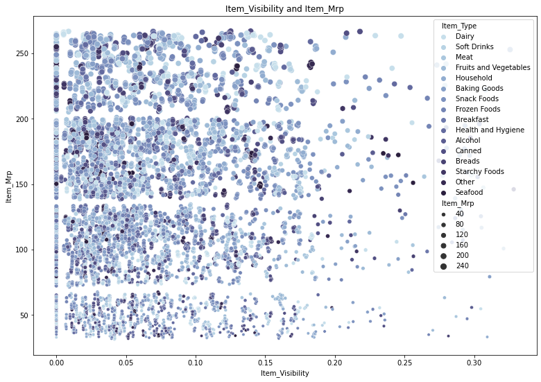

```python
# a scatter plot showing item visibility and MRP, but not sure how helpful it is? the variable can be changed to item weight etc

plt.figure(figsize=(13,9))
plt.xlabel('Item_Visibility')
plt.ylabel('Item_Mrp')
plt.title('Item_Visibility and Item_Mrp')
sns.scatterplot(x ='Item_Visibility', y = 'Item_Mrp', hue = 'Item_Type', size = 'Item_Mrp', data = train, palette = "ch:s=.25,rot=-.25")
```

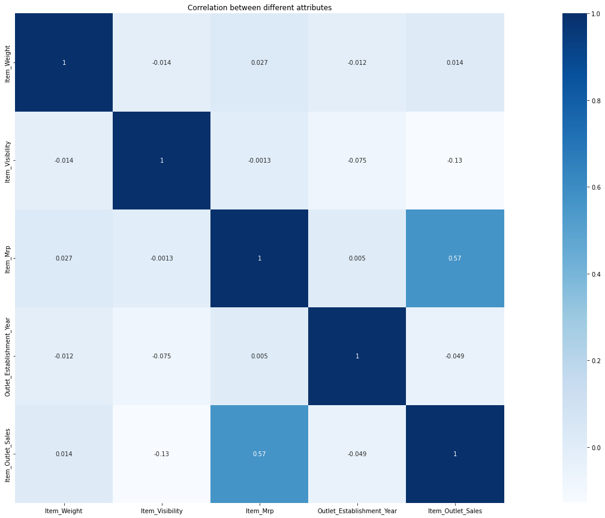

```python
# correlation map between variables

plt.figure(figsize=(35,15))
sns.heatmap(train.corr(), vmax=1, square = True, annot = True, cmap = 'Blues')
plt.title('Correlation between different attributes')
plt.show()
```

### One Hot Encoding Categorical Variables

https://www.google.com/search?q=purpose+of+one+hot+encoding&oq=purpose+of+one+hot+encoding&aqs=chrome..69i57j0i22i30l3j0i390l3.4760j1j7&sourceid=chrome&ie=UTF-8

```python
# Import library:

from sklearn.preprocessing import LabelEncoder

le = LabelEncoder()

# New Variable for Outlet

df['Outlet'] = le.fit_transform(df['Outlet_Id'])

var = ['Item_Fat_Content', 'Outlet_Location_Type', 'Outlet_Size', 'New_Item_Type', 'Outlet_Type', 'Outlet']
le = LabelEncoder()
for i in var:
    df[i] = le.fit_transform(df[i])
```

```python
df.head()
```

|  | Item_Id | Item_Weight | Item_Fat_Content | Item_Visibility | Item_Type | Item_Mrp | Outlet_Id | Outlet_Establishment_Year | Outlet_Size | Outlet_Location_Type | Outlet_Type | Item_Outlet_Sales | Source | New_Item_Type | item_visib_avg | Outlet_Years | Outlet |
| --- | --- | --- | --- | --- | --- | --- | --- | --- | --- | --- | --- | --- | --- | --- | --- | --- | --- |
| 0 | FDA15 | 9.30 | 0 | 0.016047 | Dairy | 249.8092 | OUT049 | 1999 | 1 | 0 | 1 | 3735.1380 | train | 1 | 0.931078 | 10 | 9 |
| 1 | DRC01 | 5.92 | 2 | 0.019278 | Soft Drinks | 48.2692 | OUT018 | 2009 | 1 | 2 | 2 | 443.4228 | train | 0 | 0.933420 | 0 | 3 |
| 2 | FDN15 | 17.50 | 0 | 0.016760 | Meat | 141.6180 | OUT049 | 1999 | 1 | 0 | 1 | 2097.2700 | train | 1 | 0.960069 | 10 | 9 |
| 3 | FDX07 | 19.20 | 2 | 0.000000 | Fruits and Vegetables | 182.0950 | OUT010 | 1998 | 1 | 2 | 0 | 732.3800 | train | 1 | 0.000000 | 11 | 0 |
| 4 | NCD19 | 8.93 | 1 | 0.000000 | Household | 53.8614 | OUT013 | 1987 | 0 | 2 | 1 | 994.7052 | train | 2 | 0.000000 | 22 | 1 |

```python
#dummies
df = pd.get_dummies(df, columns=['Item_Fat_Content','Outlet_Location_Type','Outlet_Size','Outlet_Type','New_Item_Type','Outlet'])
df.dtypes
```

```
Item_Id                       object
Item_Weight                  float64
Item_Visibility              float64
Item_Type                     object
Item_Mrp                     float64
Outlet_Id                     object
Outlet_Establishment_Year      int64
Item_Outlet_Sales            float64
Source                        object
item_visib_avg               float64
Outlet_Years                   int64
Item_Fat_Content_0             uint8
Item_Fat_Content_1             uint8
Item_Fat_Content_2             uint8
Outlet_Location_Type_0         uint8
Outlet_Location_Type_1         uint8
Outlet_Location_Type_2         uint8
Outlet_Size_0                  uint8
Outlet_Size_1                  uint8
Outlet_Size_2                  uint8
Outlet_Type_0                  uint8
Outlet_Type_1                  uint8
Outlet_Type_2                  uint8
Outlet_Type_3                  uint8
New_Item_Type_0                uint8
New_Item_Type_1                uint8
New_Item_Type_2                uint8
Outlet_0                       uint8
Outlet_1                       uint8
Outlet_2                       uint8
Outlet_3                       uint8
Outlet_4                       uint8
Outlet_5                       uint8
Outlet_6                       uint8
Outlet_7                       uint8
Outlet_8                       uint8
Outlet_9                       uint8
dtype: object
```

## Model Buliding

```python
# drop item_type

df.drop(['Item_Type', 'Outlet_Establishment_Year'],axis=1, inplace=True)
```

```python
# split test and train back

train = df.loc[df['Source'] == 'train']
test = df.loc[df['Source'] == 'test']
```

```python
train.drop(['Source'],axis=1,inplace=True)
```

```python
train
```

|  | Item_Id | Item_Weight | Item_Visibility | Item_Mrp | Outlet_Id | Item_Outlet_Sales | item_visib_avg | Outlet_Years | Item_Fat_Content_0 | Item_Fat_Content_1 | ... | Outlet_0 | Outlet_1 | Outlet_2 | Outlet_3 | Outlet_4 | Outlet_5 | Outlet_6 | Outlet_7 | Outlet_8 | Outlet_9 |
| --- | --- | --- | --- | --- | --- | --- | --- | --- | --- | --- | --- | --- | --- | --- | --- | --- | --- | --- | --- | --- | --- |
| 0 | FDA15 | 9.300 | 0.016047 | 249.8092 | OUT049 | 3735.1380 | 0.931078 | 10 | 1 | 0 | ... | 0 | 0 | 0 | 0 | 0 | 0 | 0 | 0 | 0 | 1 |
| 1 | DRC01 | 5.920 | 0.019278 | 48.2692 | OUT018 | 443.4228 | 0.933420 | 0 | 0 | 0 | ... | 0 | 0 | 0 | 1 | 0 | 0 | 0 | 0 | 0 | 0 |
| 2 | FDN15 | 17.500 | 0.016760 | 141.6180 | OUT049 | 2097.2700 | 0.960069 | 10 | 1 | 0 | ... | 0 | 0 | 0 | 0 | 0 | 0 | 0 | 0 | 0 | 1 |
| 3 | FDX07 | 19.200 | 0.000000 | 182.0950 | OUT010 | 732.3800 | 0.000000 | 11 | 0 | 0 | ... | 1 | 0 | 0 | 0 | 0 | 0 | 0 | 0 | 0 | 0 |
| 4 | NCD19 | 8.930 | 0.000000 | 53.8614 | OUT013 | 994.7052 | 0.000000 | 22 | 0 | 1 | ... | 0 | 1 | 0 | 0 | 0 | 0 | 0 | 0 | 0 | 0 |
| ... | ... | ... | ... | ... | ... | ... | ... | ... | ... | ... | ... | ... | ... | ... | ... | ... | ... | ... | ... | ... | ... |
| 8518 | FDF22 | 6.865 | 0.056783 | 214.5218 | OUT013 | 2778.3834 | 0.874001 | 22 | 1 | 0 | ... | 0 | 1 | 0 | 0 | 0 | 0 | 0 | 0 | 0 | 0 |
| 8519 | FDS36 | 8.380 | 0.046982 | 108.1570 | OUT045 | 549.2850 | 1.001096 | 7 | 0 | 0 | ... | 0 | 0 | 0 | 0 | 0 | 0 | 0 | 1 | 0 | 0 |
| 8520 | NCJ29 | 10.600 | 0.035186 | 85.1224 | OUT035 | 1193.1136 | 0.998881 | 5 | 0 | 1 | ... | 0 | 0 | 0 | 0 | 0 | 0 | 1 | 0 | 0 | 0 |
| 8521 | FDN46 | 7.210 | 0.145221 | 103.1332 | OUT018 | 1845.5976 | 1.041620 | 0 | 0 | 0 | ... | 0 | 0 | 0 | 1 | 0 | 0 | 0 | 0 | 0 | 0 |
| 8522 | DRG01 | 14.800 | 0.044878 | 75.4670 | OUT046 | 765.6700 | 1.027777 | 12 | 1 | 0 | ... | 0 | 0 | 0 | 0 | 0 | 0 | 0 | 0 | 1 | 0 |

8523 rows × 34 columns

```python
test
```

|  | Item_Id | Item_Weight | Item_Visibility | Item_Mrp | Outlet_Id | Item_Outlet_Sales | Source | item_visib_avg | Outlet_Years | Item_Fat_Content_0 | ... | Outlet_0 | Outlet_1 | Outlet_2 | Outlet_3 | Outlet_4 | Outlet_5 | Outlet_6 | Outlet_7 | Outlet_8 | Outlet_9 |
| --- | --- | --- | --- | --- | --- | --- | --- | --- | --- | --- | --- | --- | --- | --- | --- | --- | --- | --- | --- | --- | --- |
| 8523 | FDW58 | 20.750000 | 0.007565 | 107.8622 | OUT049 | NaN | test | 1.029192 | 10 | 1 | ... | 0 | 0 | 0 | 0 | 0 | 0 | 0 | 0 | 0 | 1 |
| 8524 | FDW14 | 8.300000 | 0.038428 | 87.3198 | OUT017 | NaN | test | 1.130311 | 2 | 0 | ... | 0 | 0 | 1 | 0 | 0 | 0 | 0 | 0 | 0 | 0 |
| 8525 | NCN55 | 14.600000 | 0.099575 | 241.7538 | OUT010 | NaN | test | 1.735215 | 11 | 0 | ... | 1 | 0 | 0 | 0 | 0 | 0 | 0 | 0 | 0 | 0 |
| 8526 | FDQ58 | 7.315000 | 0.015388 | 155.0340 | OUT017 | NaN | test | 1.291577 | 2 | 1 | ... | 0 | 0 | 1 | 0 | 0 | 0 | 0 | 0 | 0 | 0 |
| 8527 | FDY38 | 12.792854 | 0.118599 | 234.2300 | OUT027 | NaN | test | 0.917824 | 24 | 0 | ... | 0 | 0 | 0 | 0 | 0 | 1 | 0 | 0 | 0 | 0 |
| ... | ... | ... | ... | ... | ... | ... | ... | ... | ... | ... | ... | ... | ... | ... | ... | ... | ... | ... | ... | ... | ... |
| 14199 | FDB58 | 10.500000 | 0.013496 | 141.3154 | OUT046 | NaN | test | 0.874729 | 12 | 0 | ... | 0 | 0 | 0 | 0 | 0 | 0 | 0 | 0 | 1 | 0 |
| 14200 | FDD47 | 7.600000 | 0.142991 | 169.1448 | OUT018 | NaN | test | 0.878292 | 0 | 0 | ... | 0 | 0 | 0 | 1 | 0 | 0 | 0 | 0 | 0 | 0 |
| 14201 | NCO17 | 10.000000 | 0.073529 | 118.7440 | OUT045 | NaN | test | 1.162245 | 7 | 0 | ... | 0 | 0 | 0 | 0 | 0 | 0 | 0 | 1 | 0 | 0 |
| 14202 | FDJ26 | 15.300000 | 0.000000 | 214.6218 | OUT017 | NaN | test | 0.000000 | 2 | 0 | ... | 0 | 0 | 1 | 0 | 0 | 0 | 0 | 0 | 0 | 0 |
| 14203 | FDU37 | 9.500000 | 0.104720 | 79.7960 | OUT045 | NaN | test | 1.029678 | 7 | 0 | ... | 0 | 0 | 0 | 0 | 0 | 0 | 0 | 1 | 0 | 0 |

5681 rows × 35 columns

```python
test1 = test

test1.drop(['Item_Outlet_Sales','Source'],axis=1,inplace=True)
#test1 = test.drop(['Item_Outlet_Sales','Source'],axis=1,inplace=True)
```

```python
test
```

|  | Item_Id | Item_Weight | Item_Visibility | Item_Mrp | Outlet_Id | item_visib_avg | Outlet_Years | Item_Fat_Content_0 | Item_Fat_Content_1 | Item_Fat_Content_2 | ... | Outlet_0 | Outlet_1 | Outlet_2 | Outlet_3 | Outlet_4 | Outlet_5 | Outlet_6 | Outlet_7 | Outlet_8 | Outlet_9 |
| --- | --- | --- | --- | --- | --- | --- | --- | --- | --- | --- | --- | --- | --- | --- | --- | --- | --- | --- | --- | --- | --- |
| 8523 | FDW58 | 20.750000 | 0.007565 | 107.8622 | OUT049 | 1.029192 | 10 | 1 | 0 | 0 | ... | 0 | 0 | 0 | 0 | 0 | 0 | 0 | 0 | 0 | 1 |
| 8524 | FDW14 | 8.300000 | 0.038428 | 87.3198 | OUT017 | 1.130311 | 2 | 0 | 0 | 1 | ... | 0 | 0 | 1 | 0 | 0 | 0 | 0 | 0 | 0 | 0 |
| 8525 | NCN55 | 14.600000 | 0.099575 | 241.7538 | OUT010 | 1.735215 | 11 | 0 | 1 | 0 | ... | 1 | 0 | 0 | 0 | 0 | 0 | 0 | 0 | 0 | 0 |
| 8526 | FDQ58 | 7.315000 | 0.015388 | 155.0340 | OUT017 | 1.291577 | 2 | 1 | 0 | 0 | ... | 0 | 0 | 1 | 0 | 0 | 0 | 0 | 0 | 0 | 0 |
| 8527 | FDY38 | 12.792854 | 0.118599 | 234.2300 | OUT027 | 0.917824 | 24 | 0 | 0 | 1 | ... | 0 | 0 | 0 | 0 | 0 | 1 | 0 | 0 | 0 | 0 |
| ... | ... | ... | ... | ... | ... | ... | ... | ... | ... | ... | ... | ... | ... | ... | ... | ... | ... | ... | ... | ... | ... |
| 14199 | FDB58 | 10.500000 | 0.013496 | 141.3154 | OUT046 | 0.874729 | 12 | 0 | 0 | 1 | ... | 0 | 0 | 0 | 0 | 0 | 0 | 0 | 0 | 1 | 0 |
| 14200 | FDD47 | 7.600000 | 0.142991 | 169.1448 | OUT018 | 0.878292 | 0 | 0 | 0 | 1 | ... | 0 | 0 | 0 | 1 | 0 | 0 | 0 | 0 | 0 | 0 |
| 14201 | NCO17 | 10.000000 | 0.073529 | 118.7440 | OUT045 | 1.162245 | 7 | 0 | 1 | 0 | ... | 0 | 0 | 0 | 0 | 0 | 0 | 0 | 1 | 0 | 0 |
| 14202 | FDJ26 | 15.300000 | 0.000000 | 214.6218 | OUT017 | 0.000000 | 2 | 0 | 0 | 1 | ... | 0 | 0 | 1 | 0 | 0 | 0 | 0 | 0 | 0 | 0 |
| 14203 | FDU37 | 9.500000 | 0.104720 | 79.7960 | OUT045 | 1.029678 | 7 | 0 | 0 | 1 | ... | 0 | 0 | 0 | 0 | 0 | 0 | 0 | 1 | 0 | 0 |

5681 rows × 33 columns

```python
X_train = train.drop(['Item_Outlet_Sales','Item_Id','Outlet_Id'],axis=1)
y_train = train['Item_Outlet_Sales']


X_test = test1.drop(['Item_Id','Outlet_Id'],axis=1).copy()
# generate y test?
#y_test = test['Item_Outlet_Sales']
```

```python
# predictive dataset on dummy dataset

X_test.head()
```

|  | Item_Weight | Item_Visibility | Item_Mrp | item_visib_avg | Outlet_Years | Item_Fat_Content_0 | Item_Fat_Content_1 | Item_Fat_Content_2 | Outlet_Location_Type_0 | Outlet_Location_Type_1 | ... | Outlet_0 | Outlet_1 | Outlet_2 | Outlet_3 | Outlet_4 | Outlet_5 | Outlet_6 | Outlet_7 | Outlet_8 | Outlet_9 |
| --- | --- | --- | --- | --- | --- | --- | --- | --- | --- | --- | --- | --- | --- | --- | --- | --- | --- | --- | --- | --- | --- |
| 8523 | 20.750000 | 0.007565 | 107.8622 | 1.029192 | 10 | 1 | 0 | 0 | 1 | 0 | ... | 0 | 0 | 0 | 0 | 0 | 0 | 0 | 0 | 0 | 1 |
| 8524 | 8.300000 | 0.038428 | 87.3198 | 1.130311 | 2 | 0 | 0 | 1 | 0 | 1 | ... | 0 | 0 | 1 | 0 | 0 | 0 | 0 | 0 | 0 | 0 |
| 8525 | 14.600000 | 0.099575 | 241.7538 | 1.735215 | 11 | 0 | 1 | 0 | 0 | 0 | ... | 1 | 0 | 0 | 0 | 0 | 0 | 0 | 0 | 0 | 0 |
| 8526 | 7.315000 | 0.015388 | 155.0340 | 1.291577 | 2 | 1 | 0 | 0 | 0 | 1 | ... | 0 | 0 | 1 | 0 | 0 | 0 | 0 | 0 | 0 | 0 |
| 8527 | 12.792854 | 0.118599 | 234.2300 | 0.917824 | 24 | 0 | 0 | 1 | 0 | 0 | ... | 0 | 0 | 0 | 0 | 0 | 1 | 0 | 0 | 0 | 0 |

5 rows × 31 columns

# Fitting Models

## Linear Regression

THIS IS NOT A CLASSIFIACTION PROBLEM

Linear regression is the next step up after correlation. It is used when we want to predict the value of a variable based on the value of another variable. The variable we want to predict is called the dependent variable (or sometimes, the outcome variable).

```python
X_train.head()
```

|  | Item_Weight | Item_Visibility | Item_Mrp | item_visib_avg | Outlet_Years | Item_Fat_Content_0 | Item_Fat_Content_1 | Item_Fat_Content_2 | Outlet_Location_Type_0 | Outlet_Location_Type_1 | ... | Outlet_0 | Outlet_1 | Outlet_2 | Outlet_3 | Outlet_4 | Outlet_5 | Outlet_6 | Outlet_7 | Outlet_8 | Outlet_9 |
| --- | --- | --- | --- | --- | --- | --- | --- | --- | --- | --- | --- | --- | --- | --- | --- | --- | --- | --- | --- | --- | --- |
| 0 | 9.30 | 0.016047 | 249.8092 | 0.931078 | 10 | 1 | 0 | 0 | 1 | 0 | ... | 0 | 0 | 0 | 0 | 0 | 0 | 0 | 0 | 0 | 1 |
| 1 | 5.92 | 0.019278 | 48.2692 | 0.933420 | 0 | 0 | 0 | 1 | 0 | 0 | ... | 0 | 0 | 0 | 1 | 0 | 0 | 0 | 0 | 0 | 0 |
| 2 | 17.50 | 0.016760 | 141.6180 | 0.960069 | 10 | 1 | 0 | 0 | 1 | 0 | ... | 0 | 0 | 0 | 0 | 0 | 0 | 0 | 0 | 0 | 1 |
| 3 | 19.20 | 0.000000 | 182.0950 | 0.000000 | 11 | 0 | 0 | 1 | 0 | 0 | ... | 1 | 0 | 0 | 0 | 0 | 0 | 0 | 0 | 0 | 0 |
| 4 | 8.93 | 0.000000 | 53.8614 | 0.000000 | 22 | 0 | 1 | 0 | 0 | 0 | ... | 0 | 1 | 0 | 0 | 0 | 0 | 0 | 0 | 0 | 0 |

5 rows × 31 columns

```python
y_train
```

```
0       3735.1380
1        443.4228
2       2097.2700
3        732.3800
4        994.7052
          ...
8518    2778.3834
8519     549.2850
8520    1193.1136
8521    1845.5976
8522     765.6700
Name: Item_Outlet_Sales, Length: 8523, dtype: float64
```

```python
from sklearn.linear_model import LinearRegression

#from sklearn.pipeline import make_pipeline

#model = make_pipeline(StandardScaler(with_mean=False), LinearRegression())

lr = LinearRegression()

lr.fit(X_train,y_train)
```

```
LinearRegression()
```

```python
lr_pred = lr.predict(X_test)
```

```python
lr_pred
```

```
array([1844.08821509, 1569.9023178 , 1871.14116321, ..., 1805.82428049,
       3573.54521621, 1263.41875663])
```

```python
lr_accuracy = round(lr.score(X_train,y_train)*100)
lr_accuracy
```

```
56
```

## Decision Tree Regressor

```python
from sklearn.tree import DecisionTreeRegressor

tree = DecisionTreeRegressor(max_depth=15, min_samples_leaf=100)

tree.fit(X_train, y_train)
tree_pred = tree.predict(X_test)
```

```python
tree_accuracy = round(tree.score(X_train, y_train)*100)
tree_accuracy
```

```
62
```

## Random Forest Regressor

```python
from sklearn.ensemble import RandomForestRegressor#

rf = RandomForestRegressor(n_estimators=400,max_depth=6,min_samples_leaf=100,n_jobs=4)
rf.fit(X_train, y_train)
#rf_pred = rf.predict(X_test)
```

```
RandomForestRegressor(max_depth=6, min_samples_leaf=100, n_estimators=400,
                      n_jobs=4)
```

```python
rf_accuracy = round(rf.score(X_train, y_train)*100)
rf_accuracy
```

```
61
```

## XGBoost Regressor

```python
#conda install -c conda-forge xgboost
```

```python
from xgboost import XGBRegressor

model = XGBRegressor(n_estimators = 100, learning_rate=0.05)
model.fit(X_train, y_train)
```

```
XGBRegressor(base_score=0.5, booster='gbtree', colsample_bylevel=1,
             colsample_bynode=1, colsample_bytree=1, enable_categorical=False,
             gamma=0, gpu_id=-1, importance_type=None,
             interaction_constraints='', learning_rate=0.05, max_delta_step=0,
             max_depth=6, min_child_weight=1, missing=nan,
             monotone_constraints='()', n_estimators=100, n_jobs=16,
             num_parallel_tree=1, predictor='auto', random_state=0, reg_alpha=0,
             reg_lambda=1, scale_pos_weight=1, subsample=1, tree_method='exact',
             validate_parameters=1, verbosity=None)
```

```python
y_pred = model.predict(X_test)
y_pred
```

```
array([1659.6506, 1297.625 ,  639.7941, ..., 1862.8121, 3716.712 ,
       1274.1649], dtype=float32)
```

```python
model.score(X_train, y_train)*100
```

```
67.72716943174717
```